# EasyVisa_Full_Code_Rahman

#### Hypertuning with Gradient boosting

```python
%%time

# Choose the type of classifier.
gboost2 = GradientBoostingClassifier(random_state=1)

# Grid of parameters to choose from
parameters = {
    'n_estimators': [50, 100, 200, 300, 400],  # Number of boosting stages
    'learning_rate': [0.01, 0.05, 0.1, 0.2, 0.5, 1.0],  # Learning rate
    'max_depth': [3, 4, 5, 6, 7],  # Maximum depth of the trees
    'min_samples_split': [2, 5, 10, 20],  # Min samples to split a node
    'min_samples_leaf': [1, 2, 5, 10],  # Min samples at a leaf node
    'max_features': ['sqrt', 'log2', None, 0.1, 0.3, 0.5, 1],  # Max features for splitting nodes
    'subsample': [0.5, 0.7, 0.8, 1.0],  # Fraction of samples used for fitting each tree
    'loss': ['log_loss', 'exponential']  # Loss function to optimize
}

# Type of scoring used to compare parameter combinations
acc_scorer = metrics.make_scorer(metrics.recall_score)

# Run the random search
grid_obj = RandomizedSearchCV(gboost2, parameters,n_iter=30, scoring=acc_scorer,cv=5, random_state = 1, n_jobs = -1, verbose = 2)
# using n_iter = 30, so randomized search will try 30 different combinations of hyperparameters
# by default, n_iter = 10

grid_obj = grid_obj.fit(X_train, y_train)

# Print the best combination of parameters
grid_obj.best_params_
```

```
Fitting 5 folds for each of 30 candidates, totalling 150 fits
CPU times: user 3.55 s, sys: 598 ms, total: 4.14 s
Wall time: 5min 30s
```

```
{'subsample': 1.0,
 'n_estimators': 50,
 'min_samples_split': 20,
 'min_samples_leaf': 2,
 'max_features': 0.1,
 'max_depth': 5,
 'loss': 'log_loss',
 'learning_rate': 1.0}
```

CV score based on this recommended parameters

```python
grid_obj.best_score_
```

```
np.float64(0.4868885037163567)
```

```python
# Set the clf to the best combination of parameters
gboost2_tuned = GradientBoostingClassifier(
 subsample= 1.0,
 n_estimators= 50,
 min_samples_split= 20,
 min_samples_leaf= 2,
 max_features= 0.1,
 max_depth= 5,
 loss= 'log_loss',
 learning_rate=1.0
)

# Fit the best algorithm to the data.
gboost2_tuned.fit(X_train, y_train)
```

```
GradientBoostingClassifier(learning_rate=1.0, max_depth=5, max_features=0.1,
                           min_samples_leaf=2, min_samples_split=20,
                           n_estimators=50)
```

Let us check the model performance based on the hypertuned parameters

```python
# Checking recall score on train and validation set
print("Recall on train and validation set")
print(recall_score(y_train, gboost2_tuned.fit(X_train, y_train)
.predict(X_train)))
print(recall_score(y_val, gboost2_tuned.fit(X_train, y_train)
.predict(X_val)))
print("")
print("Precision on train and validation set")
# Checking precision score on train and validation set
print(precision_score(y_train, gboost2_tuned.fit(X_train, y_train)
.predict(X_train)))
print(precision_score(y_val, gboost2_tuned.fit(X_train, y_train)
.predict(X_val)))
print("")
print("Accuracy on train and validation set")
# Checking accuracy score on train and validation set
print(accuracy_score(y_train, gboost2_tuned.fit(X_train, y_train)
.predict(X_train)))
print(accuracy_score(y_val, gboost2_tuned.fit(X_train, y_train)
.predict(X_val)))
```

```
Recall on train and validation set
0.5613330181990073
0.47459629775502166

Precision on train and validation set
0.7097518753606463
0.6112214498510427

Accuracy on train and validation set
0.7783359497645211
0.7234432234432234
```

## Actionable Insights and Recommendations

### Using the above three models and comparing the performance using the test data for all three

#### Decision Tree Classifer

```python
model = dt2_tuned

# Checking recall score on test set
print("Recall on test set")
print(recall_score(y_test, model.predict(X_test)))
print("")

# Checking precision score on test set
print("Precision on test set")
print(precision_score(y_test, model.predict(X_test)))
print("")

# Checking accuracy score on test set
print("Accuracy on test set")
print(accuracy_score(y_test, model.predict(X_test)))
```

```
Recall on test set
0.4781323877068558

Precision on test set
0.6524193548387097

Accuracy on test set
0.7421507064364207
```

### Ada Boosting Classifier

```python
model = ada2_tuned

# Checking recall score on test set
print("Recall on test set")
print(recall_score(y_test, model.predict(X_test)))
print("")

# Checking precision score on test set
print("Precision on test set")
print(precision_score(y_test, model.predict(X_test)))
print("")

# Checking accuracy score on test set
print("Accuracy on test set")
print(accuracy_score(y_test, model.predict(X_test)))
```

```
Recall on test set
0.516548463356974

Precision on test set
0.649331352154532

Accuracy on test set
0.7468602825745683
```

### Gradient Boosting Classifier

```python
model = gboost2_tuned

# Checking recall score on test set
print("Recall on test set")
print(recall_score(y_test, model.predict(X_test)))
print("")

# Checking precision score on test set
print("Precision on test set")
print(precision_score(y_test, model.predict(X_test)))
print("")

# Checking accuracy score on test set
print("Accuracy on test set")
print(accuracy_score(y_test, model.predict(X_test)))
```

```
Recall on test set
0.5135933806146572

Precision on test set
0.6145685997171145

Accuracy on test set
0.7315541601255887
```

Based on the above scores below are the suggestions on using the model

1. Recall: AdaBoost has the highest recall (0.5165), which means it correctly identifies more positive cases compared to the other two models.

AdaBoost and Gradient Boosting are very close in accuracy, with AdaBoost slightly outperforming Gradient Boosting.

Using the Ada boosting to get the important features

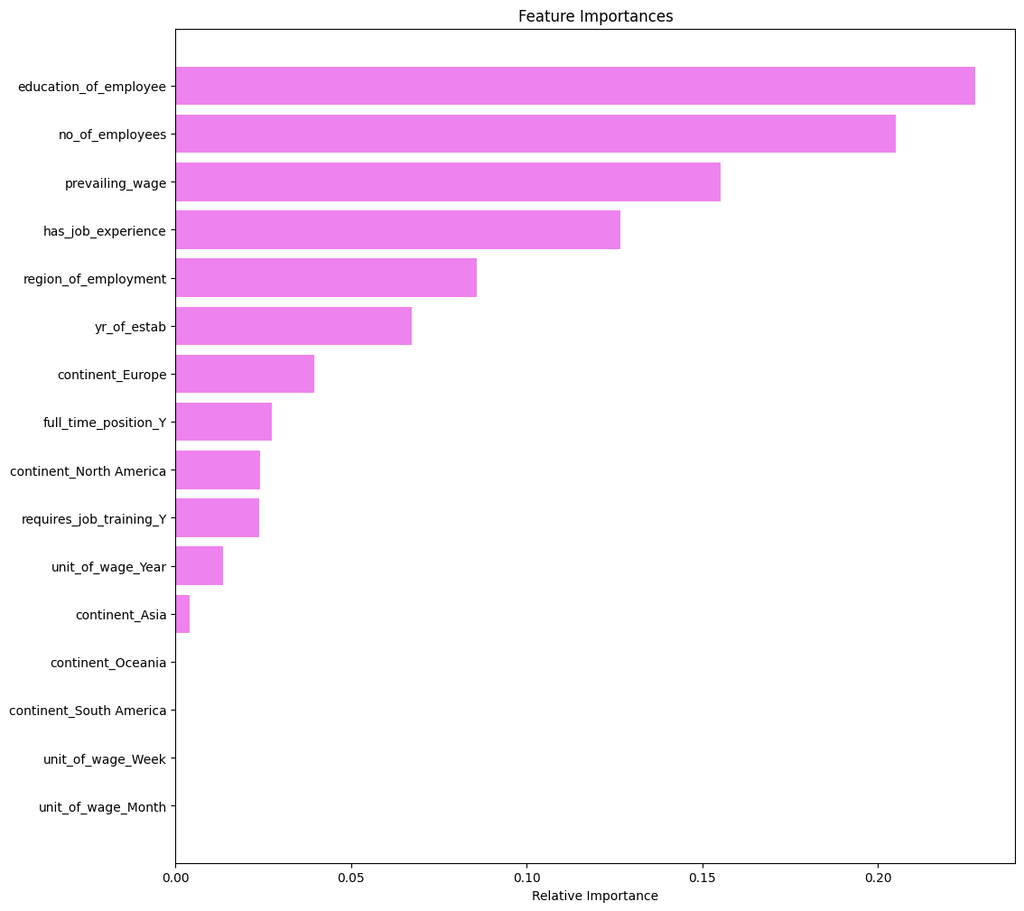

```python
importances = ada2_tuned.feature_importances_
indices = np.argsort(importances)
feature_names = list(X.columns)

plt.figure(figsize=(12,12))
plt.title('Feature Importances')
plt.barh(range(len(indices)), importances[indices], color='violet', align='center')
plt.yticks(range(len(indices)), [feature_names[i] for i in indices])
plt.xlabel('Relative Importance')
plt.show()
```

Based on the above important features from the tuned Ada Boosting model, the top 5 important features in the ranking are:

1. Education of employee
2. Number of employees
3. Prevailing wage
4. Job experience
5. Region of empoyment.

Power Ahead